# Q1_Q2

```python
pip install geopandas
```

```
  Using cached geopandas-0.10.2-py2.py3-none-any.whl (1.0 MB)
  Using cached pyproj-3.2.1-cp37-cp37m-manylinux2010_x86_64.whl (6.3 MB)
```

```python
pip install earthpy
```

```
  Using cached earthpy-0.9.4-py3-none-any.whl (1.4 MB)
```

```python
pip install rioxarray
```

```
Processing ./.cache/pip/wheels/0a/e5/fb/5ac6dcd7faf126d92239d03f0e7d6c46648094d7a8706d2a63/rioxarray-0.8.0-py3-none-any.whl
  Using cached xarray-0.20.1-py3-none-any.whl (835 kB)
  Attempting uninstall: xarray
    Found existing installation: xarray 0.16.0
    Uninstalling xarray-0.16.0:
      Successfully uninstalled xarray-0.16.0
```

## Q1

```python
import os

import numpy as np
import matplotlib.pyplot as plt
import seaborn as sns
import rioxarray as rxr
import earthpy as et

# Prettier plotting with seaborn
sns.set(font_scale=1.5, style="whitegrid")
```

```python
# Set initial catalog
os.chdir(os.path.join(et.io.HOME,
                      'earth-analytics',
                      'data'))
```

```python
# Define relative path to file
data_path = os.path.join("colorado-flood",
                         "spatial",
                         "outputs")

pre_chm_data_path = os.path.join(data_path, "pre-flood-chm.tif")

# Open lidar chm
lidar_chm = rxr.open_rasterio(pre_chm_data_path, masked = True).squeeze()
lidar_chm
```

```
<xarray.DataArray (y: 2000, x: 4000)>
[8000000 values with dtype=float32]
Coordinates:
    band         int64 1
  * x            (x) float64 4.72e+05 4.72e+05 4.72e+05 ... 4.76e+05 4.76e+05
  * y            (y) float64 4.436e+06 4.436e+06 ... 4.434e+06 4.434e+06
    spatial_ref  int64 0
Attributes:
    scale_factor:  1.0
    add_offset:    0.0
```

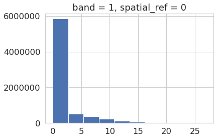

```
<xarray.DataArray (y: 2000, x: 4000)>
array([[     nan,      nan,      nan, ..., 0.      , 0.170044, 0.960083],
       [     nan,      nan,      nan, ..., 0.      , 0.090088, 1.640015],
       [     nan,      nan,      nan, ..., 0.      , 0.      , 0.079956],
       ...,
       [     nan,      nan,      nan, ..., 0.      , 0.      , 0.      ],
       [     nan,      nan,      nan, ..., 0.      , 0.      , 0.      ],
       [     nan,      nan,      nan, ..., 0.      , 0.      , 0.      ]],
      dtype=float32)
Coordinates:
    band         int64 1
  * x            (x) float64 4.72e+05 4.72e+05 4.72e+05 ... 4.76e+05 4.76e+05
  * y            (y) float64 4.436e+06 4.436e+06 ... 4.434e+06 4.434e+06
    spatial_ref  int64 0
Attributes:
    scale_factor:  1.0
    add_offset:    0.0
```

```python
# Plot histogram to check if there is no data value
lidar_chm.plot.hist()
plt.show()
lidar_chm
```

```python
# Check dimension of the CHM file
lidar_chm.shape
```

```
(2000, 4000)
```

From part 2, we know that the correct crs of this CHM raster file is **EPSG:32613** and there should be no "no data value.

```python
# Does lidar_chm GeoTIFF file has the correct crs and 'no data value'?
print(lidar_chm.rio.crs)
print(lidar_chm.rio.nodata)
```

```
EPSG:32613
None
```

It shows that the crs of lidar_chm is **EPSG:32613**, which match up the correct one. Also, "no data value" is none since the output of lidar_chm.rio.nodata is '**None**'.

```python
# Does lidar_chm GeoTIFF file has the correct resolution?
# Define relative path to file
lidar_dsm_path = os.path.join("colorado-flood",
                              "spatial",
                              "boulder-leehill-rd",
                              "pre-flood",
                              "lidar",
                              "pre_DSM.tif")


# Open lidar dem
lidar_dsm_xr = rxr.open_rasterio(lidar_dsm_path, masked=True).squeeze()
lidar_dsm_xr
```

```
<xarray.DataArray (y: 2000, x: 4000)>
[8000000 values with dtype=float32]
Coordinates:
    band         int64 1
  * x            (x) float64 4.72e+05 4.72e+05 4.72e+05 ... 4.76e+05 4.76e+05
  * y            (y) float64 4.436e+06 4.436e+06 ... 4.434e+06 4.434e+06
    spatial_ref  int64 0
Attributes:
    scale_factor:  1.0
    add_offset:    0.0
```

The correct resolution should be as same as the one with DSM and DEM. From part 2, we already know that DSM and DEM does have the same crs, 'no data value', and resolution. Now, all we need to do is to verify this CHM has the same resolution as DSM.

```python
print("Is the resolution of CHM as same as the resolution of DSM? The result is: ",
      lidar_chm.rio.resolution() == lidar_dsm_xr.rio.resolution())
```

```
Is the resolution of CHM as same as the resolution of DSM? The result is:  True
```

So the resolution is also correct!

```python
print("The resolution of CHM is:", lidar_chm.rio.resolution())
```

```
The resolution of CHM is: (1.0, -1.0)
```

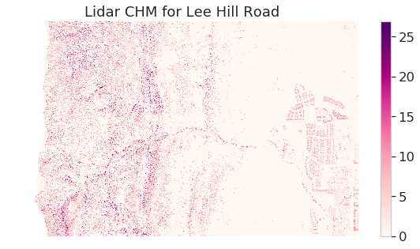

```python
# Plot the data
f, ax = plt.subplots(figsize=(10, 5))
lidar_chm.plot(cmap="RdPu")
ax.set(title="Lidar CHM for Lee Hill Road")
ax.set_axis_off()
plt.show()
```

## Q2 Part 1

```python
# Import necessary packages
import os

import matplotlib.pyplot as plt
from matplotlib.colors import ListedColormap, BoundaryNorm
import numpy as np
import xarray as xr
import rioxarray as rxr
import earthpy as et
import earthpy.plot as ep

# Prettier plotting with seaborn
import seaborn as sns
sns.set(font_scale=1.5, style="whitegrid")
```

```python
## set working directory
os.chdir(os.path.join(et.io.HOME,
                      'earth-analytics',
                      'data'))
```

```python
# Define relative paths to DTM and DSM files of Pre-flood
pre_dtm_path = os.path.join("colorado-flood",
                        "spatial",
                        "boulder-leehill-rd",
                        "pre-flood",
                        "lidar",
                        "pre_DTM.tif")

pre_dsm_path = os.path.join("colorado-flood",
                        "spatial",
                        "boulder-leehill-rd",
                        "pre-flood",
                        "lidar",
                        "pre_DSM.tif")

# Open DTM and DSM files
pre_lidar_dtm = rxr.open_rasterio(pre_dtm_path, masked=True).squeeze()
pre_lidar_dsm = rxr.open_rasterio(pre_dsm_path, masked=True).squeeze()

# Create canopy height model (CHM) of Pre flood
pre_lidar_chm = pre_lidar_dsm - pre_lidar_dtm

# Define relative paths to DTM and DSM files of Post-flood
post_dtm_path = os.path.join("colorado-flood",
                             "spatial",
                             "boulder-leehill-rd",
                             "post-flood",
                             "lidar",
                             "post_DTM.tif")

post_dsm_path = os.path.join("colorado-flood",
                             "spatial",
                             "boulder-leehill-rd",
                             "post-flood",
                             "lidar",
                             "post_DSM.tif")

# Open DTM and DSM files
post_lidar_dtm = rxr.open_rasterio(post_dtm_path, masked=True).squeeze()
post_lidar_dsm = rxr.open_rasterio(post_dsm_path, masked=True).squeeze()

# Create canopy height model (CHM) of Post flood
post_lidar_chm = post_lidar_dsm - post_lidar_dtm
```

```python
# Check if they have the same bounds, crs, no data, and resolution.
# Are the bounds the same?
print("Is the spatial extent the same?",
      post_lidar_chm.rio.bounds() == pre_lidar_chm.rio.bounds())

# Is the resolution the same ?
print("Is the resolution the same?",
      post_lidar_chm.rio.resolution() == pre_lidar_chm.rio.resolution())

# Is the crs the same?
print("Is the crs the same?",
     post_lidar_chm.rio.crs == pre_lidar_chm.rio.crs)

# No data value?
print("The no data value of post_lidar_chm is", post_lidar_chm.rio.nodata)
print("The no data value of pre_lidar_chm is", pre_lidar_chm.rio.nodata)
```

```
Is the spatial extent the same? True
Is the resolution the same? True
Is the crs the same? True
The no data value of post_lidar_chm is None
The no data value of pre_lidar_chm is None
```

Codes above shows that these two canopy height models have the same attributes for plotting.

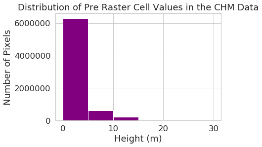

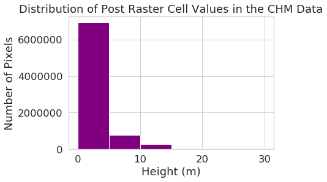

```python
# check the content of these two CHMs
f, ax = plt.subplots()
pre_lidar_chm.plot.hist(color="purple",
                       bins=[0, 5, 10, 15, 20, 30])
ax.set(title="Distribution of Pre Raster Cell Values in the CHM Data",
       xlabel="Height (m)",
       ylabel="Number of Pixels")
plt.show()

f, ax = plt.subplots()
post_lidar_chm.plot.hist(color="purple",
                        bins=[0, 5, 10, 15, 20, 30])
ax.set(title="Distribution of Post Raster Cell Values in the CHM Data",
       xlabel="Height (m)",
       ylabel="Number of Pixels")
plt.show()
```

```python
# Minimum and Maximum value from both CHMs file
pre_data_min_value = np.nanmin(pre_lidar_chm)
pre_data_max_value = np.nanmax(pre_lidar_chm)

post_data_min_value = np.nanmin(post_lidar_chm)
post_data_max_value = np.nanmax(post_lidar_chm)
```

```python
print(pre_data_min_value, pre_data_max_value)
print(post_data_min_value, post_data_max_value)
```

```
0.0 26.930054
0.0 27.439941
```

```python
# Create file that shows positive and negative change in CHM
diff_post_pre_flood = post_lidar_chm - pre_lidar_chm
diff_post_pre_flood
```

```
<xarray.DataArray (y: 2000, x: 4000)>
array([[        nan,         nan,         nan, ...,  0.        ,
        -0.17004395,  0.02001953],
       [        nan,         nan,         nan, ...,  0.        ,
        -0.09008789, -0.23999023],
       [        nan,         nan,         nan, ...,  0.        ,
         0.        , -0.07995605],
       ...,
       [        nan,         nan,         nan, ...,  0.        ,
         0.        ,  0.        ],
       [        nan,         nan,         nan, ...,  0.        ,
         0.        ,  0.        ],
       [        nan,         nan,         nan, ...,  0.        ,
         0.        ,  0.        ]], dtype=float32)
Coordinates:
    band         int64 1
  * x            (x) float64 4.72e+05 4.72e+05 4.72e+05 ... 4.76e+05 4.76e+05
  * y            (y) float64 4.436e+06 4.436e+06 ... 4.434e+06 4.434e+06
    spatial_ref  int64 0
```

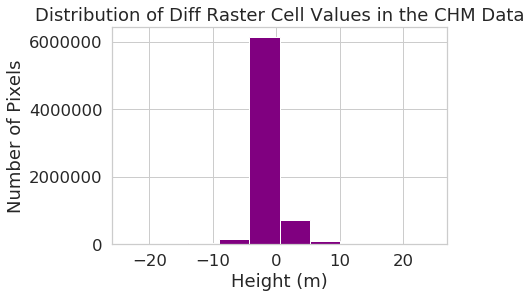

```python
# Histogram of diff_post_pre_flood CHM file
# This allows us to know which boundaries of class we're going to use
f, ax = plt.subplots()
diff_post_pre_flood.plot.hist(color="purple")
ax.set(title="Distribution of Diff Raster Cell Values in the CHM Data",
       xlabel="Height (m)",
       ylabel="Number of Pixels")
plt.show()
```

It can be seen that the value is between -10 to 10. So the range of bins are confirmed.

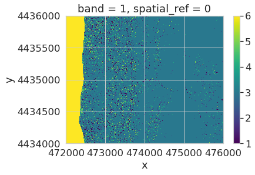

```python
# Set class bins and use xarray to apply numpy's digitize function
class_bins = [-np.inf, -5, -2, 2, 5, np.inf]
diff_post_pre_flood_class = xr.apply_ufunc(np.digitize,
                                          diff_post_pre_flood,
                                          class_bins)

# Plot the image to check which value is representing the missing data
diff_post_pre_flood_class.plot.imshow()
```

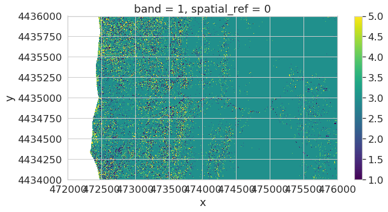

```python
# Use function "where" to unselect value represent missing value
diff_post_pre_flood_class_ma = diff_post_pre_flood_class.where(diff_post_pre_flood_class != 6)
f, ax = plt.subplots(figsize=(10,5))
# Plot newly classified and masked raster
diff_post_pre_flood_class_ma.plot.imshow()
```

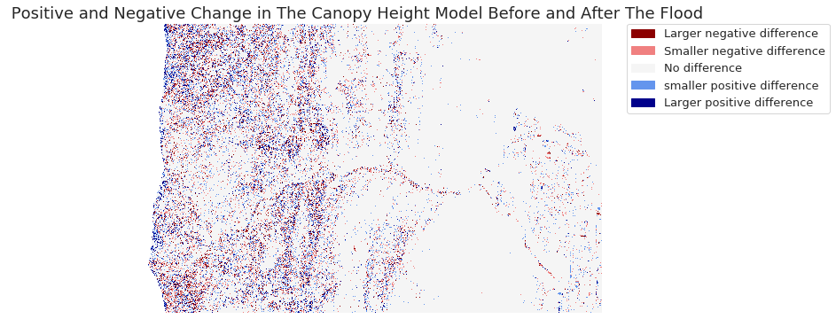

```python
# Create new class bins
class_bins = [0, 1.5, 2.5, 3.5, 4.5, 5.5]

# Create a colormap from a list of colors
colors = ['darkred',
          'lightcoral',
          'whitesmoke',
          'cornflowerblue',
          'darkblue']

cmap = ListedColormap(colors)

# Create a list of labels for legend
height_class_labels = ['Larger negative difference',
                       'Smaller negative difference',
                       'No difference',
                       'smaller positive difference',
                       'Larger positive difference']

# Set boundary and color attributes for classfication
norm = BoundaryNorm(class_bins,
                    len(colors))

# Plot the raster map
f, ax = plt.subplots(figsize=(10,6))
# Remove color bar
im = diff_post_pre_flood_class_ma.plot.imshow(cmap = cmap,
                                              norm = norm,
                                              add_colorbar=False)
# Add legend
ep.draw_legend(im, titles=height_class_labels)

# Add title
ax.set(title=" Positive and Negative Change in The Canopy Height Model Before and After The Flood")

# Remove both x-axis and y-axis to only show the map content
ax.set_axis_off()
plt.show()
```

### Explanation (Working Process):

The first step to achieve this part is of course import related packages such as earthpy, rioxarray, and numpy (In cell 13). Then, setting up the initial catalog. This is important because we need to set up Tdirectory to access and load raster files. According to this question, we need two raster files, one DTM, one DSM, from pre flood and post flood respectively. Here we adjust relative paths to those files and obtain CHM files by calculating "pre_flood_dsm" minus "pre_flood_dtm" and "post_flood_dsm" minus "post_flood_dtm" also respectively. From practices, we know that there are no data value in each DTM and DSM, we need to remove them by using function "squeeze", and we also need to check if they have the same crs, resolution(In cell 18). To double check if there is any no data value, plot histogram of each CHM files (In cell 19). Since we are looking for the difference between these two CHM files, we need to calculate post_chm minus pre_chm (In cell 22). Once we have thet CHM file of difference between pre flood and post flood, we're ready to working forward.\ To make a plot that present useful information, first thing we need to do is determining how do we plot the map. Draw a histogram plot of difference between pre flood and post flood to see which bins are data mostly located (In cell 23). Once confirmed, we're able to decide which bins are we going to use and draw our map. Here, data are mainly distributed between -10 and 10, and this determines that we need to draw a diverging map. and then plot it. This is the key step to reclassify raster data. It clearly shows that area present the value of 6 is not what we need, so we remove it.(In cell 24 and cell 25).Here, the value of 1 stands for "-np.inf", the value of 2 stands for "-5", the value of 3 stands for "-2", the value of 4 stands for "2", the value of 5 stands for "5", the value of 6 stands for "np.inf". Before we remove the data with value of 6, there are 6 classes. Once we removed it, there would be only 5 classes left. Now we reclassify the raster data and only select data we need. \ The final part is making this reclassified plot. The key manipulation here is set correct bins. We cannot use previous bins here cause we need a new bins that work with reclassfied data, and we need to let each bin include the integer value (mentioned above), so the first bin better start with 0 and end with 1.5. In this case, the value of 1 and value around it are included in this bin. Then, add title and legend. (In cell 26)

### Q2 Part 2

```python
# Open DTM files
pre_lidar_dtm = rxr.open_rasterio(pre_dtm_path, masked=True).squeeze()
post_lidar_dtm = rxr.open_rasterio(post_dtm_path, masked=True).squeeze()

# This file record the positive and negative change of terrain before and after the flood
terrain_lidar_dtm = post_lidar_dtm - pre_lidar_dtm
```

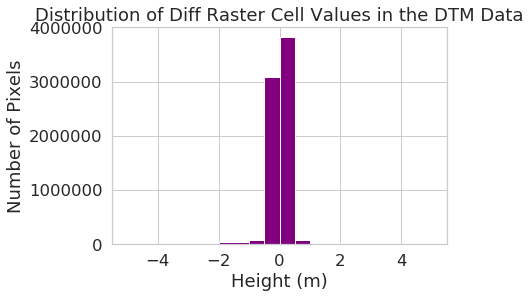

```python
# Histogram of DTM files
f, ax = plt.subplots()
terrain_lidar_dtm.plot.hist(color="purple", bins=[-5,-2,-1,-0.5,0,0.5, 1,2,5])
ax.set(title="Distribution of Diff Raster Cell Values in the DTM Data",
       xlabel="Height (m)",
       ylabel="Number of Pixels")
plt.show()
```

```python
# Minimum and Maximum value of terrain_lidar_dtm
data_min_value = np.nanmin(terrain_lidar_dtm)
data_max_value = np.nanmax(terrain_lidar_dtm)
print(data_min_value, data_max_value)
```

```
-19.609985 47.100098
```

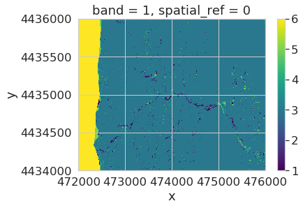

```python
# Set class bins and use xarray to apply numpy's digitize function
class_bins = [-np.inf,-1,-0.5,0.5,1,np.inf]
terrain_lidar_dtm_class = xr.apply_ufunc(np.digitize,
                                          terrain_lidar_dtm,
                                          class_bins)
terrain_lidar_dtm_class.plot.imshow()
```

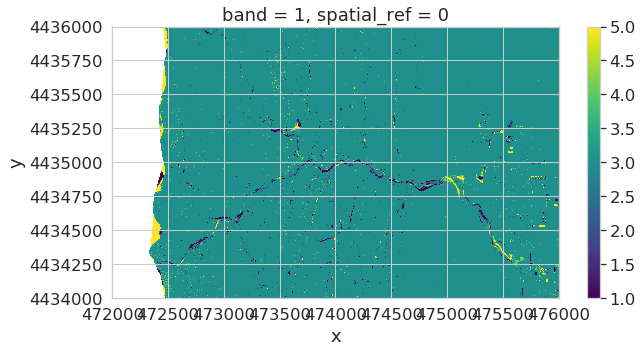

```python
# Use function "where" to unselect value that represent 6
terrain_lidar_dtm_class_ma = terrain_lidar_dtm_class.where(terrain_lidar_dtm_class !=6)
f, ax = plt.subplots(figsize=(10,5))
# Plot newly classified raster map
terrain_lidar_dtm_class_ma.plot.imshow()
```

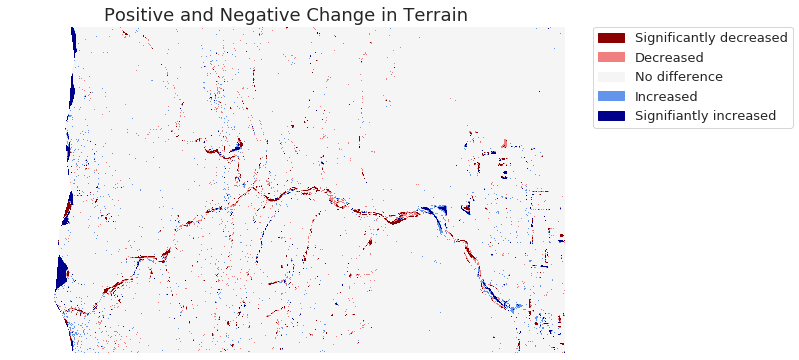

```python
# Create a colormap from a list of colors
colors = ['darkred',
          'lightcoral',
          'whitesmoke',
          'cornflowerblue',
          'darkblue']

# Create a list of labels to use on legend
height_class_labels = ['Significantly decreased',
                       'Decreased',
                       'No difference',
                       'Increased',
                       'Signifiantly increased']

cmap = ListedColormap(colors)

# Set boundary and color attributes for classfication
class_bins = [0, 1.5, 2.5, 3.5, 4.5, 5.5]
norm = BoundaryNorm(class_bins,
                    len(colors))

# Plot the raster map
f, ax = plt.subplots(figsize=(10,6))

# Remove color bar
im = terrain_lidar_dtm_class_ma.plot.imshow(cmap = cmap,
                                            norm = norm,
                                            add_colorbar=False)
# Add legend
ep.draw_legend(im, titles=height_class_labels)

# Add title
ax.set(title="Positive and Negative Change in Terrain")
ax.set_axis_off()
plt.show()
```

### Explanation (Working Process)

This part is similiar to part one. Here, we do not use CHM files, instead we use DTM files. Since we still explore the positive and negative change, calculating the differece by post_dtm minus pre_dtm is also necessary (In cell 27). Then, plot the histrogram to decide which bins we are going to use (In cell 28). We can see that most value are located between -2 and 2, so we can do smaller bins here such as 0.5 (In cell 30). Then, remove the value of 6 (In cell 31). Plot it with map elements (In cell 32).